# Second Degree Equations Part 4

### Cool Applications of Second Degree Equations!

## But First: Example Word Problems

We want to build a fence enclosing a $12 \text{m}^2$ rectangle. If the width of the rectangle is 4 more than its length, how much fence do we need?

Let $$x = \text{length of rectangle}$$

We know that the area is length$\cdot$width. So

\begin{gather} x(x+4) = 12 \\ x^2 + 4x = 12 \\ x^2 + 4x - 12 = 0 \\ \end{gather}

Now we can solve two ways. We can use the quadratic equation \begin{gather} x = \frac{-b \pm \sqrt{b^2 - 4ac}}{2a} \\ x = \frac{-4 \pm \sqrt{64}}{2} \\ x = 2, -6 \end{gather}

Or we can factor directly \begin{gather} x^2 + 4x - 12 = 0 \\ (x + 6)(x-2) = 0 \rightarrow x=-6, 2 \end{gather}

We take $x = 2$ (since lengths must be positive) and find the permiter is $$\boxed{P = 2 + 2 + 6 + 6 = 16}$$

## A second word problem

In seven years, Mario will be five more than the square of his current age. How old is Mario?

Let $$x = \text{the current age of Mario}$$

We are solving the following equation for $x$ \begin{gather} x^2 + 5 = x + 7 \\ x^2 - x - 2 = 0 \\ (x-2)(x+1) = 0 \rightarrow x = 2, -1 \end{gather}

Mario is $2$ years old!

## A harder word problem: optimal profit

Let's say you're selling lemonade at a lemonade stand. Let's assume

1. It costs 50 dollars to buy the stand (a one-time cost)
2. Every lemonade costs 2 dollar to make

Additionally, let's assume that the demand curve follows the equations $$D(x) = 300 - 30x$$ where $x$ is the price you are charging to sell one glass of lemonade.

We want to figure out what price we should sell our lemonade at in order to maximize profit!

Firstly, we know we have to spend $50$ dollars on our stand. Then, for every glass we sell, we lose exactly $2$ dollars. So our costs look like $$C(x) = 2(300 - 30x) + 50 = 600 - 60x + 50$$

### Step 3: figure out our profits

Our profit will be the difference between the money we make and the money we earn. So, $$P(x) = S(x) - C(x) = -30x^2 + 300x - 600 + 60x - 50$$ $$P(x) = -30x^2 + 360x - 650$$

We want to find the value of $x$ that *maximizes* P(x)$!

## Graphing P(x)

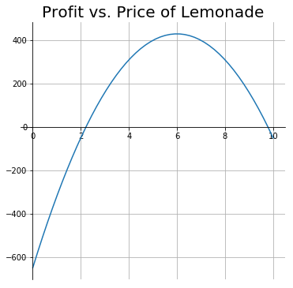

```python
x = np.linspace(0, 10)
y = -30*x**2 + 360*x - 650

fig = plt.figure(figsize=(6, 6))
ax = fig.add_subplot(111)
ax.set_title("Profit vs. Price of Lemonade", fontsize=20)
ax.plot(x, y, markersize=10)

ax.spines['left'].set_position('zero')
ax.spines['right'].set_color('none')
ax.spines['bottom'].set_position('zero')
ax.spines['top'].set_color('none')
ax.xaxis.set_ticks_position('bottom')
ax.yaxis.set_ticks_position('left')
#ax.yaxis.set_major_locator(ticker.MultipleLocator(1))

ax.grid(True)

#ax.set_ylim([0, 40])
```

## Maximum Profit

$$P(x) = -30x^2 + 360x - 650$$

The maximum profit will be at the *highest* point of our parabola: the *vertex*!

We can calculate the vertex as

\begin{align} \left(x_{ver}, y_{ver}\right) &= \left( \frac{-b}{2a}, \frac{-(b^2 - 4ac)}{4a} \right) \\ &= \left( \frac{-360}{-60}, \frac{-(360^2 - 4(-30)(-650)}{-120} \right) \\ &= \left( 6, 430 \right) \end{align}

So, we can get a maximum of profit of $430$ dollars by charging $6$ dollars for every cup of lemonade. Cool!

## Some Cool Applications of Second Degree Equations

## Linear Regression

Let's say we recorded the following data.

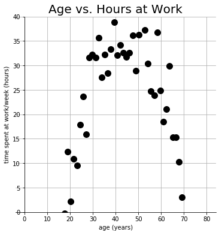

```python
def plot(x, y, plot_fit):
    #x = np.array([point[0] for point in data])
    #y = np.array([point[1] for point in data])

    fig = plt.figure(figsize=(6, 6))
    ax = fig.add_subplot(111)
    ax.set_title("Age vs. Hours at Work", fontsize=20)
    ax.plot(x, y, marker='o', markersize=10, linewidth=0, color="black")

    ax.spines['left'].set_position('zero')
    ax.spines['right'].set_color('none')
    ax.spines['bottom'].set_position('zero')
    ax.spines['top'].set_color('none')
    ax.xaxis.set_ticks_position('bottom')
    ax.yaxis.set_ticks_position('left')
    #ax.yaxis.set_major_locator(ticker.MultipleLocator(1))

    ax.grid(True)

    ax.set_ylim([0, 40])
    #ax.set_xlim([0, 50])

    ax.set_xlabel("age (years)")
    ax.set_ylabel("time spent at work/week (hours)")


    if plot_fit:
        fit = np.polyfit(x, y, 2)

        fit_x = np.linspace(0, 80)
        fit_y = np.polyval(fit, fit_x)

        ax.plot(fit_x, fit_y)


x = np.linspace(0, 80, 60)
y = -0.05*x**2 + 4.4*x -60
np.random.seed(1)
noise = np.random.normal(0, 6, 60)
y = y +  noise
plot(x,y, False)
```

It looks like we can possibly model this with a parabola!

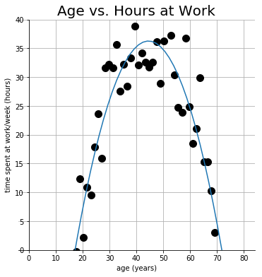

```python
def plot(x, y, plot_fit):
    #x = np.array([point[0] for point in data])
    #y = np.array([point[1] for point in data])

    fig = plt.figure(figsize=(6, 6))
    ax = fig.add_subplot(111)
    ax.set_title("Age vs. Hours at Work", fontsize=20)
    ax.plot(x, y, marker='o', markersize=10, linewidth=0, color="black")

    ax.spines['left'].set_position('zero')
    ax.spines['right'].set_color('none')
    ax.spines['bottom'].set_position('zero')
    ax.spines['top'].set_color('none')
    ax.xaxis.set_ticks_position('bottom')
    ax.yaxis.set_ticks_position('left')
    #ax.yaxis.set_major_locator(ticker.MultipleLocator(1))

    ax.grid(True)

    ax.set_ylim([0, 40])
    #ax.set_xlim([0, 50])

    ax.set_xlabel("age (years)")
    ax.set_ylabel("time spent at work/week (hours)")


    if plot_fit:
        fit = np.polyfit(x, y, 2)

        fit_x = np.linspace(0, 80)
        fit_y = np.polyval(fit, fit_x)

        ax.plot(fit_x, fit_y)


x = np.linspace(0, 80, 60)
y = -0.05*x**2 + 4.4*x -60
np.random.seed(1)
noise = np.random.normal(0, 6, 60)
y = y +  noise
plot(x,y, True)
```

Let's learn how the computer figures out this fit!

## Error

We need to figure out a way to measure how "bad" a fit is. Let's say we have a guess to our answer and want to calculate how bad one point is.

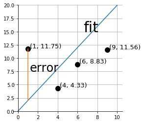

```python
def plot(x, y, plot_fit):
    #x = np.array([point[0] for point in data])
    #y = np.array([point[1] for point in data])

    fig = plt.figure(figsize=(4, 4))
    ax = fig.add_subplot(111)
    #ax.set_title("Age vs. Hours at Work", fontsize=20)
    ax.plot(x, y, marker='o', markersize=10, linewidth=0, color="black")

    for i in range(len(x)):
        ax.annotate("(" + str(np.round(x[i], 2)) + ", "  + str(np.round(y[i], 2))+ ")", (x[i]+0.2, y[i]+0.2), fontsize=13)


    ax.spines['left'].set_position('zero')
    ax.spines['right'].set_color('none')
    ax.spines['bottom'].set_position('zero')
    ax.spines['top'].set_color('none')
    ax.xaxis.set_ticks_position('bottom')
    ax.yaxis.set_ticks_position('left')
    #ax.yaxis.set_major_locator(ticker.MultipleLocator(1))
    ax.annotate("fit", (6.6, 15), fontsize="30")


    ax.grid(True)

    ax.set_ylim([0, 20])
    #ax.set_xlim([0, 50])

    #ax.set_xlabel("age (years)")
    #ax.set_ylabel("time spent at work/week (hours)")


    if plot_fit:
        #fit = np.polyfit(x, y, 2)

        fit_x = np.linspace(0, 10)
        fit_y = 2*fit_x

        ax.plot(fit_x, fit_y)

        # Draw error of one point
        x_error = np.array([1, 1])
        y_error = np.array([y[0], 2*x[0]])
        ax.plot(x_error, y_error)
        ax.annotate("error", (1.2, 7.5), fontsize=24)


x = np.array([1, 4, 6, 9])
y = 2*x
np.random.seed(1)
noise = np.random.normal(0, 6, 4)
y = y +  noise
plot(x,y, True)
```

If our point is located at $\left(x_i, y_i)\right)$ then we can calculate the error as

$$\text{error} = \left(y_i - fit(x_i)\right)^2$$

Why is this squared?

## Error

We can calculate how bad a fit is by summing up the error of each point!

$$\text{badness} = \sum_{\text{all points}} \left(y_i - fit(x_i)\right)^2$$

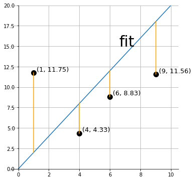

```python
def plot(x, y, plot_fit):
    #x = np.array([point[0] for point in data])
    #y = np.array([point[1] for point in data])

    fig = plt.figure(figsize=(6, 6))
    ax = fig.add_subplot(111)
    #ax.set_title("Age vs. Hours at Work", fontsize=20)
    ax.plot(x, y, marker='o', markersize=10, linewidth=0, color="black")

    for i in range(len(x)):
        ax.annotate("(" + str(np.round(x[i], 2)) + ", "  + str(np.round(y[i], 2))+ ")", (x[i]+0.2, y[i]+0.2), fontsize=13)


    ax.spines['left'].set_position('zero')
    ax.spines['right'].set_color('none')
    ax.spines['bottom'].set_position('zero')
    ax.spines['top'].set_color('none')
    ax.xaxis.set_ticks_position('bottom')
    ax.yaxis.set_ticks_position('left')
    #ax.yaxis.set_major_locator(ticker.MultipleLocator(1))
    ax.annotate("fit", (6.6, 15), fontsize="30")


    ax.grid(True)

    ax.set_ylim([0, 20])
    #ax.set_xlim([0, 50])

    #ax.set_xlabel("age (years)")
    #ax.set_ylabel("time spent at work/week (hours)")


    if plot_fit:
        #fit = np.polyfit(x, y, 2)

        fit_x = np.linspace(0, 10)
        fit_y = 2*fit_x

        ax.plot(fit_x, fit_y)

        for i in range(len(x)):
            # Draw error of one point
            x_error = np.array([x[i], x[i]])
            y_error = np.array([y[i], 2*x[i]])
            ax.plot(x_error, y_error, color="orange")
            #ax.annotate("error", (1.2, 7.5), fontsize=24)


x = np.array([1, 4, 6, 9])
y = 2*x
np.random.seed(1)
noise = np.random.normal(0, 6, 4)
y = y +  noise
plot(x,y, True)
```

Our goal is to *find a fit that minimizes badness*.

## Machine Learning

Given our original data set, we want our computer to figure out the values for $a$ $b$ and $c$ for a parabola that minimizes badness. $$fit = ax^2 + bx + c$$

The process of figuring out these values is callled *linear regression*, which is a topic of *machine learning*.

Learning the exact way machines do this is a complicated topic, but just know there's many many different methods to do this.

## Projectile Motion

When things are thrown into the air, they follow a parabolic arc!

[figure not shown]

$$y = -\frac{1}{2}gt^2 + v_0t + y_0$$

where $$g = \text{acceleration due to gravity } (9.8)$$ $$v_0 = \text{initial velocity in y-direction}$$ $$y_0 = \text{initial y position}$$

## Example Projectile Motion

A ball is thrown upwards at $3$ meters/second at a height of $2$ meters above the ground. How long does it take to hit the ground?

We have $v_0 = 3$, $y_0 = 2$, and we are solving for when $y=0$

\begin{gather} y = -\frac{1}{2}gt^2 + v_0t + y_0 \\ 0 = -\frac{1}{2}(9.8)t^2 + 3t + 2 \\ \end{gather}

Now we can use the quadratic equation to find $t$!

\begin{gather} t = \frac{-b \pm \sqrt{b^2 - 4ac}}{2a} \\ t = \frac{-3 \pm \sqrt{3^2 - 4(-4.9)(2)}}{2(-4.9)} \\ t = 1.01, -0.4 \end{gather}

Our answer is $$\boxed{t = 1.01 \text{ seconds}}$$

## Parabolas in Real Life

Parabolas are everywhere!

[figure not shown]

## Paraboloid

[figure not shown]

$$z = x^2 + y^2$$

Imagine we rotated a parabola $360^{\circ}$ around the $y$ axis.

## Paraboloids in Real Life

[figure not shown]

## Wrapping Up

- We learned a lot about how to solve second degree equations in the past 3 lessons
- Mathematics is more than just learning how to solve an equation, though
- Every day, people are using the math that you learn to solve real world problems and create real things
- Parabolas occur in the world far more often then you'd think! Keep an eye out for them!

It's been very fun teaching you all. Thank you for a great three weeks!